# Training ML models on tails

## Introduction

## Being honest: ML & money management

- ML in Finance, the **marketing paradox**:
  - ML is often a good selling point for funds/strategies;
  - but surprisingly, ML-related returns are seldom impressive.
- *One* reason: ML has become ‘easy’ because data is cheap and software free.
  - it’s great: everybody can do ML (NNs can be trained in 10 lines of code)!
  - it’s bad: ‘doing’ ML is not enough.
- Another reason: pressure leads to backtest **overfitting**.
- Yet another reason: the **communication bias towards positive results** is deceiptful:
  - people only talk about success (which is often fragile);
  - solid research/results require transparence, especially on failures.

## Possible solutions

- Successful strategies require a **deep understanding** of the implementation:
  - at the micro-level (what does the algorithm do exactly?)
  - at the macro-level (do my models/variables make sense?)
  - ths is why AutoML (one size fits all) is probably a bad idea.
- **Transparence**:
  - sharing code and data (like in the ‘general ML’ community)
  - sharing negative results and acknowledging that often seemingly good ideas don’t work: it’s ok to fail and it’s even better to admit it.

## THE ML challenge

- Most ML applications in Finance rely on **supervised learning** (SL) which tries to find patterns from data.
- The **main challenge** in supervised learning is to **extract the juice** from this data.
- Paraphrasing: it’s very hard to **separate noise from signal** in financial (and alternative) datasets.
- What I mean by signal is: the **patterns that will hold out-of-sample**.
- A model that captures those patterns is said to **generalize** well.

## The idea & first results

## Tony’s idea

SL is mostly about **predictions**. Assume we’re trying to predict returns (= labels).  
\(\rightarrow\) Filter the training sample: keep only the instances with **extreme returns**.

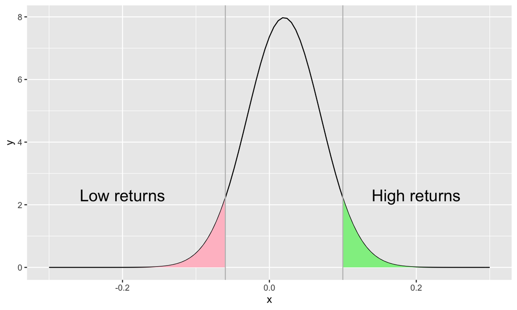

## About this idea

- **Features versus instances**: people often focus on explanatory variables (e.g., through feature selection & processing). I argue that working at the instance level could add value. I look at rows and not columns!
- **Why**? Since datasets are full of noise, filtering instances may help find a shorter path towards the signal. Also, this shrinks training times!
- **Intuition**: investors care most about high returns (they want them) and low returns (they seek to avoid them). Why bother with the rest?
- **Reproducible finance**: these slides were created in RMarkdown (all the material is available at www.gcoqueret.com/tot.html).

## The backtest: empirical protocol

- 1200 US stocks, ~100 features (accounting, risk, return, etc.)
- 2000-2017 available, 2008-2017 for backtesting (monthly rebalancing)
- ML engine: boosted trees (100 trees, \(\eta=0.3\))
1. Every month, I predict the future return of the 1200 stocks.
2. I group them in 6 groups of 200 stocks: the best, the good, the average, etc… the worse.
3. I form equally weighted portfolios of these 200 stocks.
4. I store the 1 month ahead return of each portfolio.
5. I compare the results for each of the 6 groups.

The analysis is performed on all data, on extreme returns, and on ‘bulk’ returns.

## Results

First, all ML-based portfolios yield monotonous returns w.r.t their rankings. Second, the average return of the best minus the worst portfolio is:

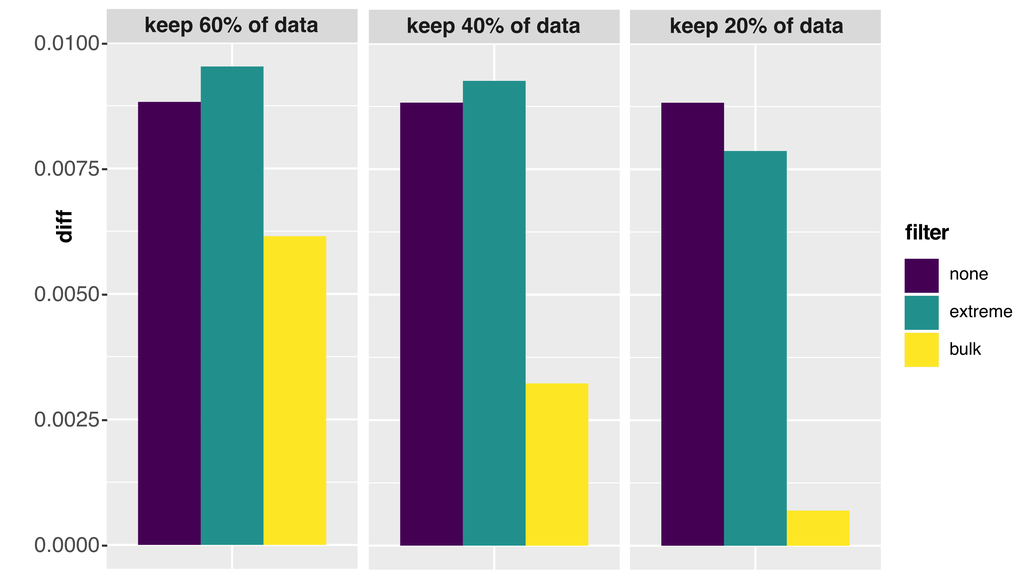

Difference between best and worst portfolios

## How does it work?

## Simple trees

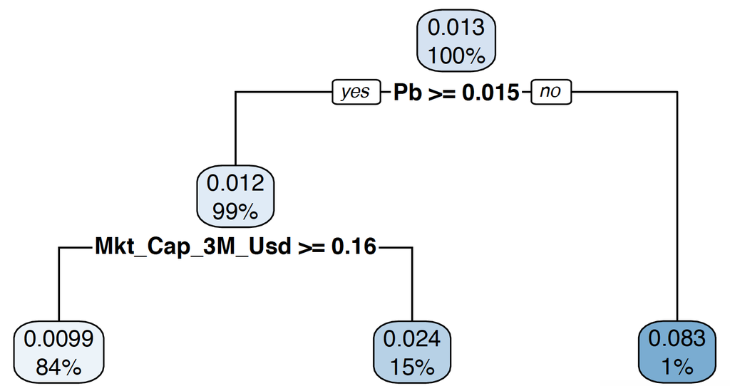

Scheme of a regression tree

For each split, two questions:  
1. Which feature?  
2. Which level (of the feature)?

## About these 2 questions

1. **Which feature?** Is it ok to let the algorithm choose that blindly?
2. **Which level for the feature?** Is any level acceptable? Said differently, do micro-clusters generalize well out-of-sample?
3. What’s the impact of a **filter** that keeps only the extreme points?

It’s impossible to answer these question theoretically.

Thus, we resort to a flexible tool: **simulations**.

## One simulation

\[y=x_1/6+\sin(10x_2)/7+\epsilon/20, \quad \epsilon \sim N(0,1)\]

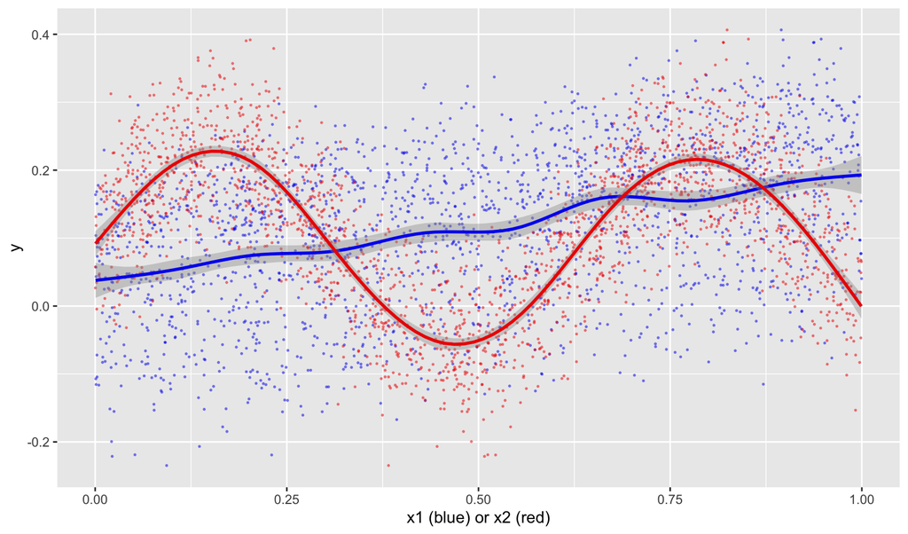

## Trees: explaining y with x1 and x2.

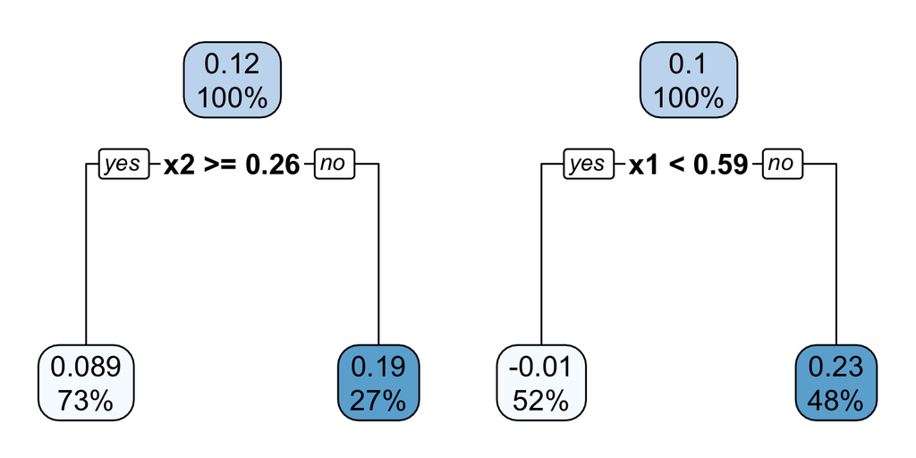

The left tree is trained with the raw data; the right trees is trained with the truncated data (top & bottom 15%).

## Visual explanation

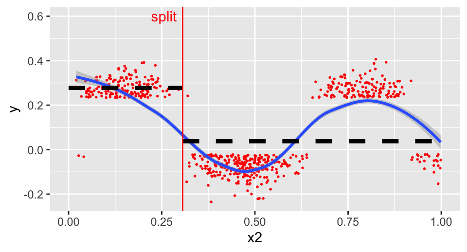

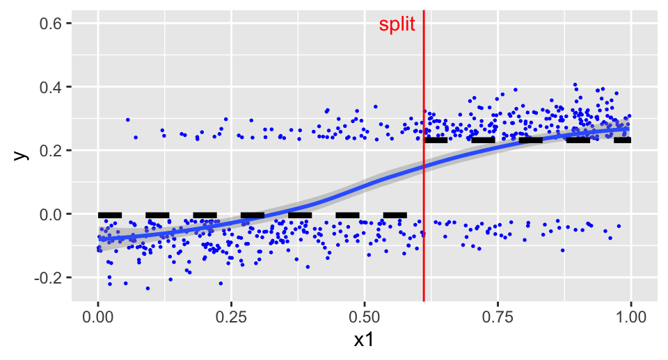

In the **first (oscillatory) case**, there is one relatively homogeneous cluster and one very inhomogeneous one. The average value in the big cluster is far from all points.

In the **linear case**, the two clusters contribute equally to dispersion. One cluster is clearly for higher values of y and the other for the lower values.

## Takeaways from the simulations

Filtering the training set and retaining only extreme instances:

- favors variables that have a **monotonic impact** on the label (except for a few pathological exceptions);
- can create **more homogenous** clusters by choosing splitting points closer to the center.

Is this **favorable**? Yes, because:

- monotonicity is a **token of robustness**;
- larger clusters are more reliable than **sample idiosyncrasies**.

## About gains in training times

For trees, the computational cost lies between \(N\log(N)\) and \(N^2\) - with \(N\) being the number of instances. Hence filtering divides training times by two to three.

This is not insignificant because the **multiplication of dimensions** is truly an issue:

- many **strategies**;
- hundreds or thousands of **assets**;
- dozens or hundreds of **features**;
- dozens of hundreds of **rebalancing dates** in a dynamic backtest;
- \(+\) **hyperparameter tuning**!

This can become overwhelming. Any gain is welcome.

## Conclusion

## It’s all about structure

- Blind machine learning algorithm all tend to overfit on *past* patterns.
- The problem is that unlike many ML problems (for which **invariance** is the key), these patterns change through time (macroeconomic conditions, investor beliefs, etc.). Solutions include:
  - ‘adding’ macro-variables to the set of predictors;
  - including time-varying views / preferences.
- One *natural* saveguard against overfitting is to add some **structure** to the models. Often, this requires a more complex optimization: a little more (constraints), a lot more (GANs for asset pricing).
- Surprisingly, altering the training data can lead the model to be more structured around solid (lasting?) relationships between the features and the label.
- \(+\) Monotonicity constraints in trees.

## Thank you for your attention

Any questions?